# EDA

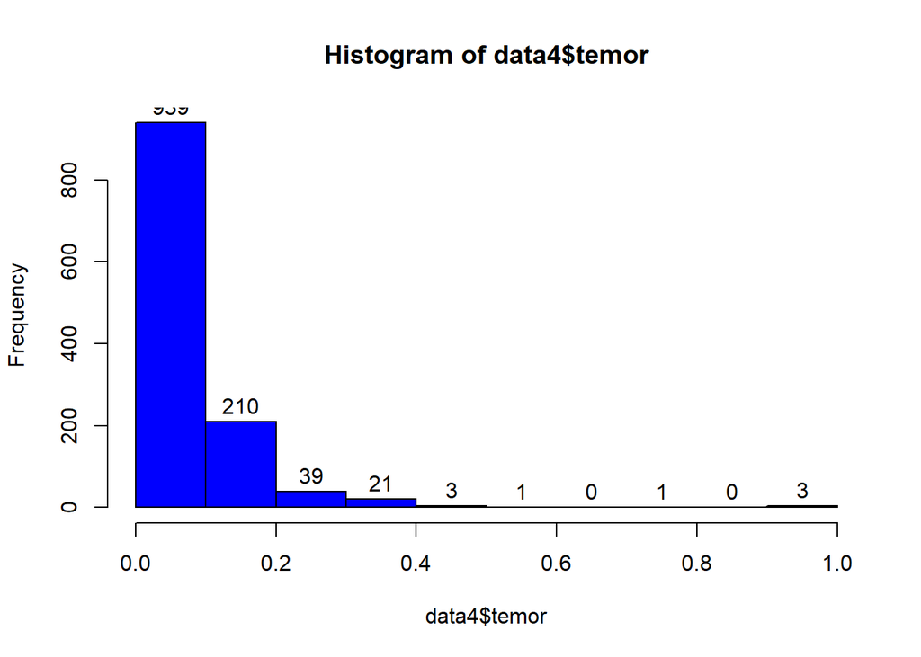

```r
hist(data4$temor, freq = T, col = "blue", labels = T)
```

**histograma de disgusto**

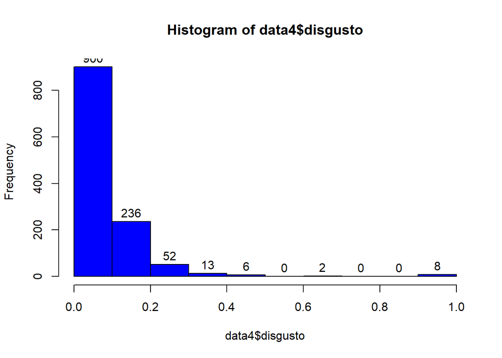

```r
hist(data4$disgusto, freq = T, col = "blue", labels = T)
```

**histograma de anticipacion**

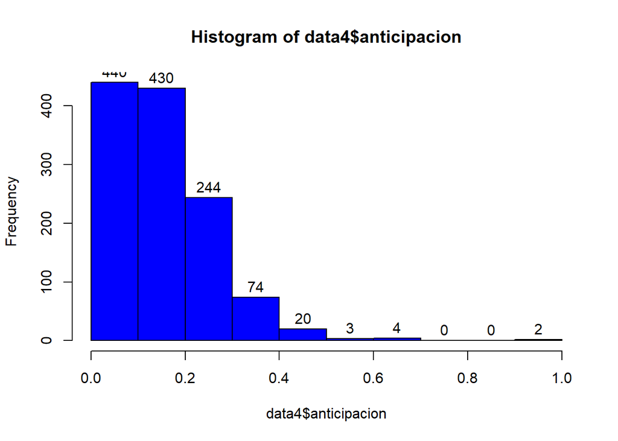

```r
hist(data4$anticipacion, freq = T, col = "blue", labels = T)
```

**histograma de enfado**

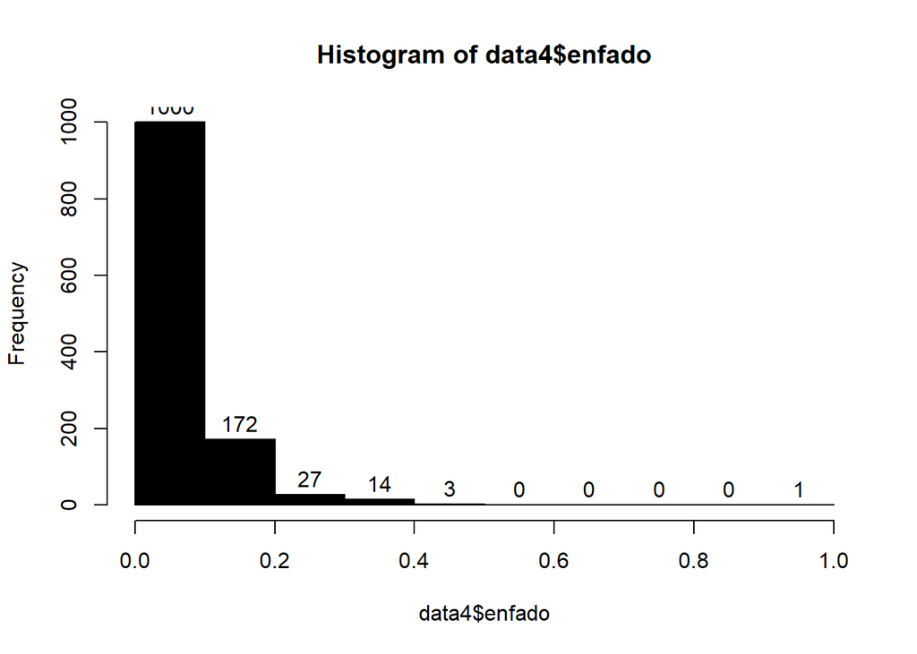

```r
hist(data4$enfado, freq = T, col = "black", labels = T)
```

**histograma de confianza**

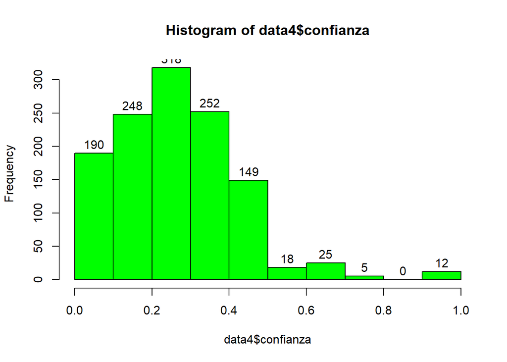

```r
hist(data4$confianza, freq = T, col = "green", labels = T)
```

# ANALISIS DE COMPONENTES PRINCIPALES

## CARGA DE DATASET

```r
dataset <- read_csv("C:/Users/KEVIN/Downloads/PCA/PCA/Rest.csv") %>%
  drop_na() %>%
  dplyr::select(-id, -name, -x, -y, -district, -direction, -n_reviews,     -min_price, -max_price)
```

## Muestra de las principales operaciones de nuestro dataset.

```r
describe(dataset)
```

```
##              vars  n mean   sd median trimmed  mad  min  max range  skew
## enfado          1 72 0.05 0.07   0.00    0.03 0.00 0.00 0.20  0.20  1.18
## anticipacion    2 72 0.13 0.11   0.14    0.12 0.12 0.00 0.44  0.44  0.47
## disgusto        3 72 0.07 0.09   0.03    0.05 0.05 0.00 0.33  0.33  1.22
## temor           4 72 0.06 0.08   0.00    0.04 0.00 0.00 0.33  0.33  1.52
## alegria         5 72 0.27 0.12   0.25    0.27 0.12 0.00 0.50  0.50  0.09
## tristesa        6 72 0.09 0.10   0.07    0.08 0.11 0.00 0.33  0.33  0.77
## sorpresa        7 72 0.06 0.08   0.05    0.05 0.07 0.00 0.29  0.29  1.09
## confianza       8 72 0.28 0.16   0.27    0.27 0.10 0.00 0.75  0.75  0.31
## negativo        9 72 0.23 0.18   0.22    0.21 0.21 0.00 0.67  0.67  0.40
## positivo       10 72 0.77 0.18   0.78    0.79 0.21 0.33 1.00  0.67 -0.40
## stars_1        11 72 0.02 0.06   0.00    0.01 0.00 0.00 0.40  0.40  3.95
## stars_2        12 72 0.04 0.07   0.01    0.02 0.01 0.00 0.38  0.38  2.80
## stars_3        13 72 0.12 0.17   0.05    0.08 0.07 0.00 0.75  0.75  1.93
## stars_4        14 72 0.35 0.20   0.31    0.34 0.19 0.01 0.92  0.91  0.61
## stars_5        15 72 0.47 0.28   0.46    0.47 0.35 0.00 0.93  0.93 -0.08
##              kurtosis   se
## enfado          -0.16 0.01
## anticipacion     0.20 0.01
## disgusto         0.77 0.01
## temor            1.63 0.01
## alegria         -0.19 0.01
## tristesa        -0.46 0.01
## sorpresa         0.32 0.01
## confianza        0.01 0.02
## negativo        -0.61 0.02
## positivo        -0.61 0.02
## stars_1         18.79 0.01
## stars_2          8.63 0.01
## stars_3          3.05 0.02
## stars_4         -0.14 0.02
## stars_5         -1.24 0.03
```

## Estandarización del dataset

```r
scale_data <- scale(dataset)
```

## Matriz varianza covarianza

```r
cov <- cov(scale_data)
```

## Matriz de correlación

```r
mtx <- cor(scale_data)
```

## Correlacion entre variables con levelplot

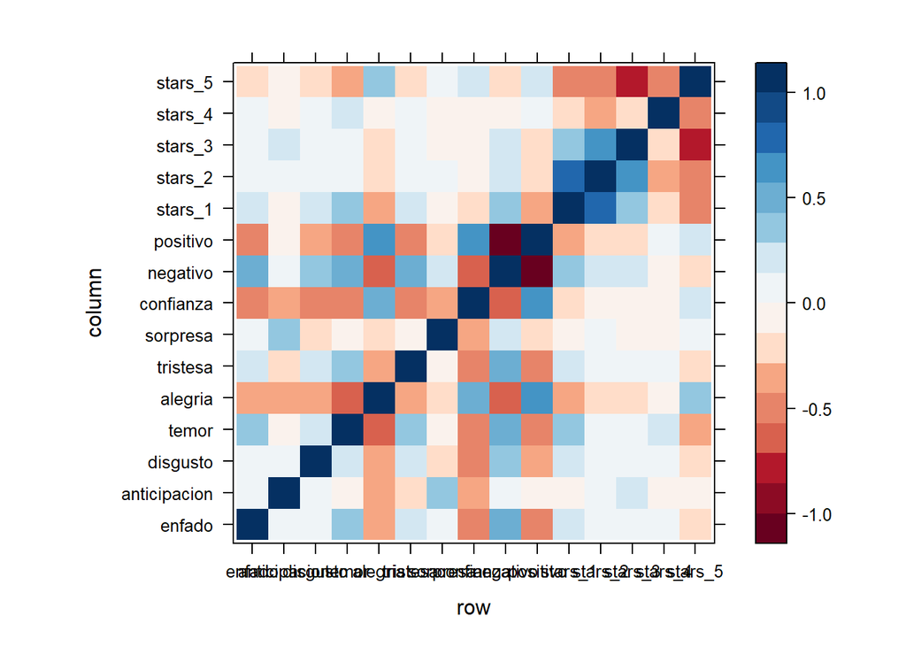

```r
levelplot(
  mtx,
  col.regions =
    cpt(
      pal = "cb_div_RdBu_11",
      n = 100, rev = F
    )
)
```

## Analizando los componentes principales

```r
pca <-
  dudi.pca(
    scale_data,
    scale = F, scannf = F,
    nf = ncol(scale_data)
  )

summary(pca)
```

```
## Class: pca dudi
## Call: dudi.pca(df = scale_data, scale = F, scannf = F, nf = ncol(scale_data))
##
## Total inertia: 14.79
##
## Eigenvalues:
##     Ax1     Ax2     Ax3     Ax4     Ax5
##   4.916   2.278   1.665   1.526   0.943
##
## Projected inertia (%):
##     Ax1     Ax2     Ax3     Ax4     Ax5
##  33.232  15.398  11.253  10.318   6.375
##
## Cumulative projected inertia (%):
##     Ax1   Ax1:2   Ax1:3   Ax1:4   Ax1:5
##   33.23   48.63   59.88   70.20   76.58
##
## (Only 5 dimensions (out of 12) are shown)
```

## Autovalores

```r
pca$eig
```

```
##  [1] 4.9155928 2.2775782 1.6645731 1.5261769 0.9429551 0.7824910 0.7033534
##  [8] 0.5685404 0.5192285 0.4105056 0.3126796 0.1679921
```

## Autovectores

```r
pca$c1
```

```
##                      CS1         CS2          CS3          CS4           CS5
## enfado       -0.27041062 -0.15074846 -0.008535871 -0.128357970  0.2584510707
## anticipacion -0.07664459 -0.08236151 -0.302258920  0.616408182 -0.1857375775
## disgusto     -0.20718256 -0.04822440  0.191907368  0.001167596 -0.8055881140
## temor        -0.30469874 -0.08618492  0.242488887  0.001705480  0.1548485639
## alegria       0.35976696  0.09376845  0.010327417 -0.255592337  0.0817811427
## tristesa     -0.24612318 -0.12814607  0.175949884 -0.227189184  0.1671639561
## sorpresa     -0.05758166 -0.18359936 -0.475360127  0.286833000  0.3232945142
## confianza     0.33325314  0.27685736  0.075892991 -0.146276902  0.0497765209
## negativo     -0.37723036 -0.16225641 -0.102278660 -0.206854547  0.0005178395
## positivo      0.37723036  0.16225641  0.102278660  0.206854547 -0.0005178395
## stars_1      -0.25621173  0.37046630 -0.106038212 -0.213567671  0.0024162617
## stars_2      -0.20503138  0.49921322 -0.204753586 -0.066575940  0.0554205110
## stars_3      -0.18648203  0.45980161 -0.064175691  0.188445544 -0.0211940655
## stars_4      -0.01743115 -0.11589098  0.611216629  0.352059770  0.2319569460
## stars_5       0.23127557 -0.40150185 -0.313609794 -0.296427942 -0.1636896450
##                      CS6         CS7         CS8         CS9         CS10
## enfado        0.50041617 -0.48233832  0.05004013  0.42824919 -0.004172466
## anticipacion  0.18891878 -0.07593779  0.32067884 -0.18114514  0.377296776
## disgusto     -0.13430413  0.02056321 -0.20007218  0.30578203 -0.130256492
## temor         0.25004317  0.44758423  0.30368958 -0.12527880 -0.547466606
## alegria      -0.01288868 -0.18701136 -0.14670669  0.24278764  0.020867952
## tristesa     -0.65847490 -0.27301411  0.35380323 -0.19635565  0.138293417
## sorpresa     -0.37099834  0.23747412 -0.35978974  0.28200562 -0.239016715
## confianza     0.18364363  0.20572687 -0.21186374 -0.35845744  0.122693859
## negativo      0.10033151  0.04324272 -0.35997129 -0.26536203  0.198314716
## positivo     -0.10033151 -0.04324272  0.35997129  0.26536203 -0.198314716
## stars_1      -0.01594868  0.35596295  0.25530901  0.28930845  0.277056753
## stars_2      -0.04141003  0.11214162  0.02287211  0.18897454  0.161710545
## stars_3      -0.03663899 -0.43580467 -0.15151848 -0.28639274 -0.418512488
## stars_4      -0.03435208  0.11879821 -0.23565116  0.15680957  0.298693021
## stars_5       0.05991364  0.07441305  0.19497832 -0.04708022 -0.057110078
##                      CS11         CS12
## enfado       -0.311922822  0.001649522
## anticipacion  0.190404117 -0.014353275
## disgusto     -0.107281783  0.040422395
## temor         0.233399280  0.104937390
## alegria       0.704645183 -0.062692728
## tristesa     -0.099111988  0.052864209
## sorpresa     -0.138534977 -0.079808050
## confianza    -0.460929955 -0.014754578
## negativo      0.163074898 -0.016287660
## positivo     -0.163074898  0.016287660
## stars_1      -0.008902736 -0.603258876
## stars_2       0.040430006  0.740620868
## stars_3       0.048068845 -0.234950320
## stars_4       0.036469964  0.015325566
## stars_5      -0.062674367  0.073659812
```

## Grafico de sedimentacion o screeplop

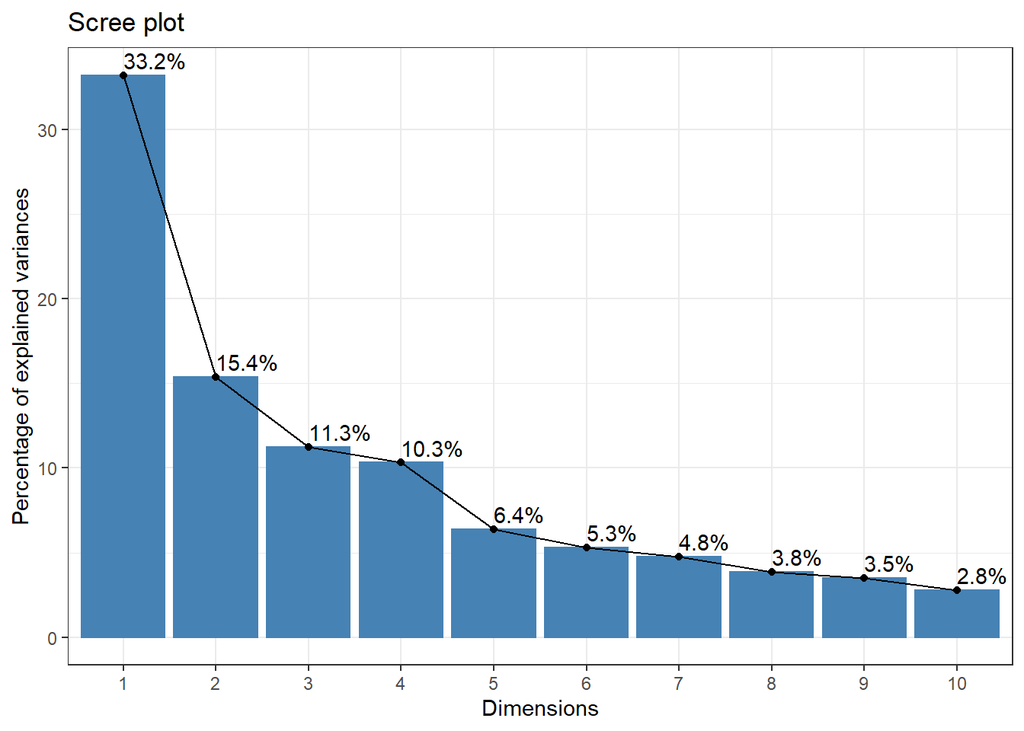

```r
fviz_eig(pca, addlabels = T) +
  theme_bw()
```

## Matriz de correlación entre los componentes principales y las variables originales

```r
pca$co
```

```
##                    Comp1       Comp2       Comp3        Comp4         Comp5
## enfado       -0.59953106 -0.22750426 -0.01101284 -0.158571553  0.2509711705
## anticipacion -0.16992976 -0.12429708 -0.38996943  0.761501629 -0.1803620976
## disgusto     -0.45934727 -0.07277857  0.24759569  0.001442431 -0.7822733772
## temor        -0.67555172 -0.13006725  0.31285513  0.002106925  0.1503670510
## alegria       0.79764423  0.14151204  0.01332426 -0.315755025  0.0794142932
## tristesa     -0.54568304 -0.19339354  0.22700761 -0.280666186  0.1623260203
## sorpresa     -0.12766509 -0.27708168 -0.61330172  0.354349282  0.3139379629
## confianza     0.73886008  0.41782337  0.09791587 -0.180708340  0.0483359256
## negativo     -0.83636256 -0.24487166 -0.13195822 -0.255545073  0.0005028526
## positivo      0.83636256  0.24487166  0.13195822  0.255545073 -0.0005028526
## stars_1      -0.56805051  0.55909467 -0.13680874 -0.263838369  0.0023463320
## stars_2      -0.45457787  0.75339499 -0.26416967 -0.082246939  0.0538165714
## stars_3      -0.41345185  0.69391639 -0.08279841  0.232802862 -0.0205806825
## stars_4      -0.03864685 -0.17489859  0.78858152  0.434929477  0.2252438193
## stars_5       0.51276422 -0.60593244 -0.40461414 -0.366202732 -0.1589522600
##                    Comp6       Comp7       Comp8       Comp9       Comp10
## enfado        0.44266074 -0.40451867  0.03773107  0.30858570 -0.002673329
## anticipacion  0.16711476 -0.06368611  0.24179702 -0.13052868  0.241736723
## disgusto     -0.11880344  0.01724558 -0.15085766  0.22033891 -0.083456259
## temor         0.22118449  0.37537175  0.22898685 -0.09027278 -0.350765742
## alegria      -0.01140113 -0.15683927 -0.11061922  0.17494673  0.013370245
## tristesa     -0.58247715 -0.22896647  0.26677335 -0.14148899  0.088605575
## sorpresa     -0.32817964  0.19916045 -0.27128728  0.20320623 -0.153139707
## confianza     0.16244844  0.17253525 -0.15974868 -0.25829551  0.078610827
## negativo      0.08875177  0.03626601 -0.27142417 -0.19121327  0.127061647
## positivo     -0.08875177 -0.03626601  0.27142417  0.19121327 -0.127061647
## stars_1      -0.01410797  0.29853249  0.19250712  0.20846847  0.177512229
## stars_2      -0.03663070  0.09404888  0.01724594  0.13617035  0.103609094
## stars_3      -0.03241031 -0.36549268 -0.11424738 -0.20636748 -0.268143923
## stars_4      -0.03038734  0.09963151 -0.17768478  0.11299307  0.191374739
## stars_5       0.05299872  0.06240737  0.14701680 -0.03392483 -0.036590832
##                    Comp11        Comp12
## enfado       -0.174420261  0.0006760871
## anticipacion  0.106469721 -0.0058829546
## disgusto     -0.059989572  0.0165678642
## temor         0.130511654  0.0430105249
## alegria       0.394021816 -0.0256957708
## tristesa     -0.055421206  0.0216673711
## sorpresa     -0.077465659 -0.0327108011
## confianza    -0.257741715 -0.0060474357
## negativo      0.091187833 -0.0066757978
## positivo     -0.091187833  0.0066757978
## stars_1      -0.004978211 -0.2472567765
## stars_2       0.022607555  0.3035571224
## stars_3       0.026879022 -0.0962987218
## stars_4       0.020393188  0.0062814659
## stars_5      -0.035046103  0.0301908326
```

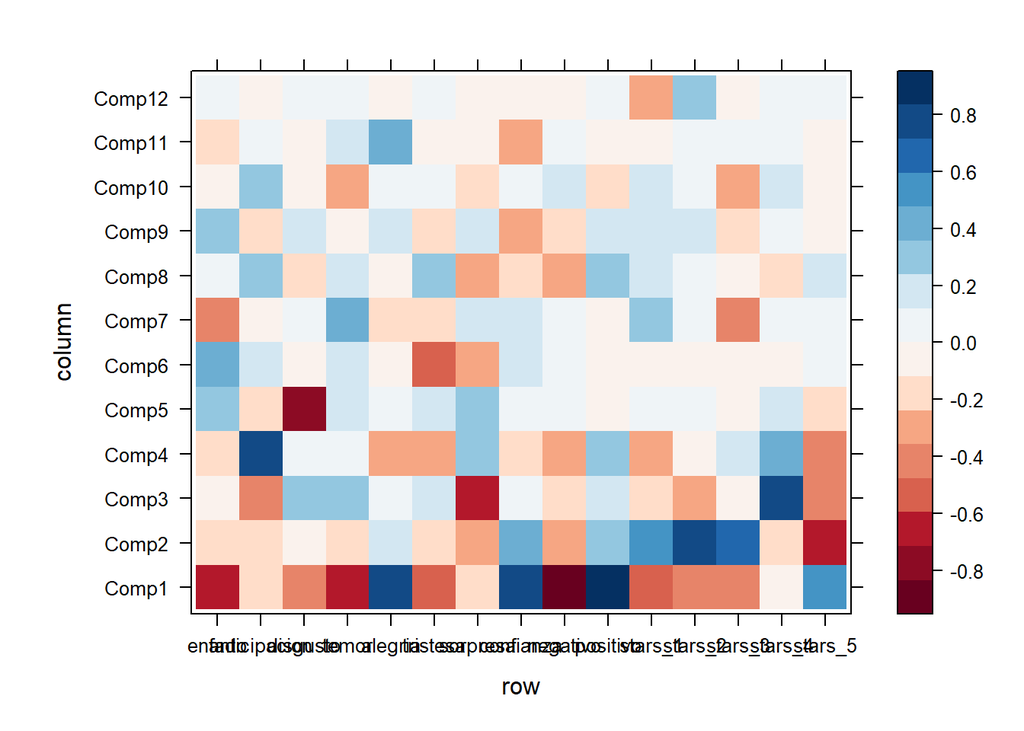

```r
levelplot(
  as.matrix(pca$co),
  col.regions =
    cpt(
      pal = "cb_div_RdBu_11", n = 100, rev = F
    )
)
```

## Contribucion de variables a los componentes

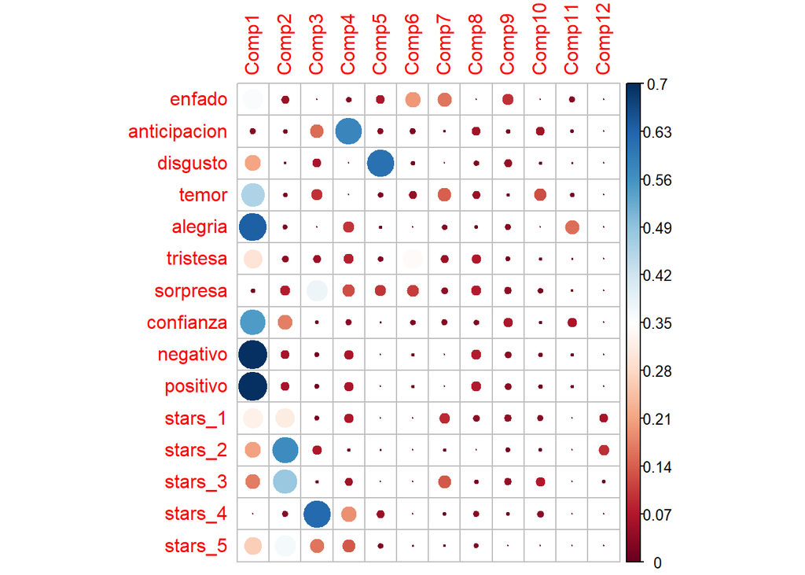

```r
contrib <- as.matrix(pca$co * pca$co)
corrplot(contrib, is.corr = F)
```

## Escores o puntuaciones

```r
as.tibble(scale_data)
```

```
## # A tibble: 72 x 15
##     enfado anticipacion disgusto  temor alegria tristesa sorpresa confianza
##      <dbl>        <dbl>    <dbl>  <dbl>   <dbl>    <dbl>    <dbl>     <dbl>
##  1 -0.664         0.966   0.0859  0.238  -0.320  -0.926     0.194    0.197
##  2 -0.664         0.674  -0.792  -0.671   1.05   -0.926     1.82    -0.458
##  3 -0.664        -1.22   -0.792  -0.671   1.86   -0.926    -0.824    1.37
##  4 -0.664         2.99   -0.792  -0.671  -0.389  -0.926    -0.824    0.353
##  5 -0.664         0.885   0.476  -0.671   0.509  -0.926     0.647   -0.323
##  6  0.776        -0.275  -0.792   0.511  -0.569   0.0928    0.500    0.151
##  7  1.74         -1.22    1.11    3.27   -2.18    2.47     -0.824   -1.67
##  8  0.0936       -0.225   0.409  -0.671   0.367  -0.390     0.569   -0.0735
##  9  1.74          1.15   -0.792   0.314  -0.838  -0.926     0.279   -0.154
## 10 -0.664         0.358  -0.792  -0.671   0.509  -0.926     1.38     0.353
## # ... with 62 more rows, and 7 more variables: negativo <dbl>, positivo <dbl>,
## #   stars_1 <dbl>, stars_2 <dbl>, stars_3 <dbl>, stars_4 <dbl>, stars_5 <dbl>
```

```r
head(pca$li)
```

```
##         Axis1       Axis2       Axis3      Axis4      Axis5      Axis6
## 1  0.98384967 -0.02425660  0.07588004  1.5220669 -0.4074784  0.3174599
## 2  2.42162512 -0.82440804 -2.09847205  0.8286878  0.2890048 -0.5166813
## 3  3.18859190  1.24005493  0.29944776 -1.0098829  0.1684991  0.3227865
## 4  0.99064330 -0.05559773 -2.04361250  1.1359565 -1.0593641  1.2406163
## 5  1.92937049 -0.56465910 -0.79774053  1.1201649 -0.9533690 -0.2322958
## 6 -0.06266269 -0.87896497  1.06610434  0.6620358  1.4948172  0.3063759
##        Axis7      Axis8       Axis9     Axis10      Axis11      Axis12
## 1  0.7207227  0.4192645  0.08509750 -0.1526704 -0.09690988 -0.01472370
## 2  0.3075691  0.4402946  0.96731582 -0.6373238  0.48588026 -0.23280000
## 3 -0.3579065 -0.1207206 -0.02230599 -0.6739738  0.34197014 -0.23452309
## 4  0.1817374  1.5313020 -1.19829776  1.5063083  0.29945661  0.30630980
## 5  0.2093922  0.4760215  0.93547871 -0.2089856  0.16728889 -0.08297668
## 6  0.3136724 -0.1561121  0.31473851  0.1035824 -0.65802772  0.04845251
```

```r
output <-
  as.tibble(pca$li) %>%
  dplyr::select(sprintf("Axis%1$s", 1:5))
```

# cluster

### jerarquico

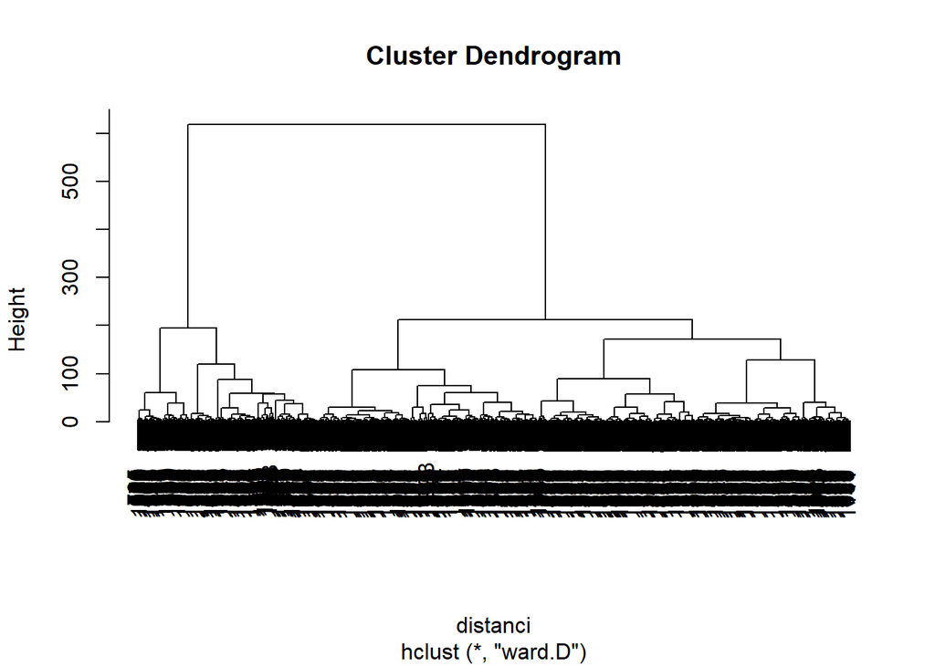

```r
clus <- data3 %>% dplyr::select(-id, -name,-n_reviews,-min_price)
distanci <- dist(scale(clus), method = "euclidean") # estandariza
hmodel <- hclust(distanci, method = "ward.D")
plot(hmodel)
```

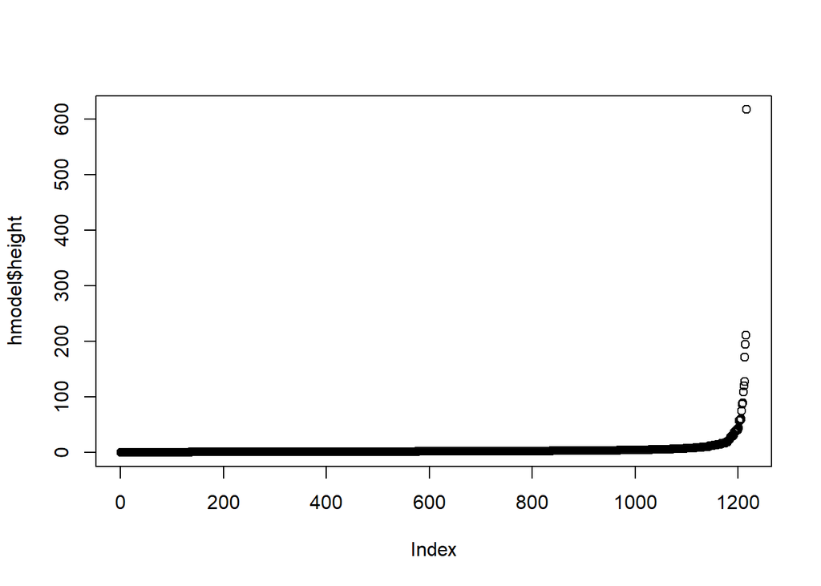

```r
plot(hmodel$height, type = "p")
```

```r
library(rgl)
```

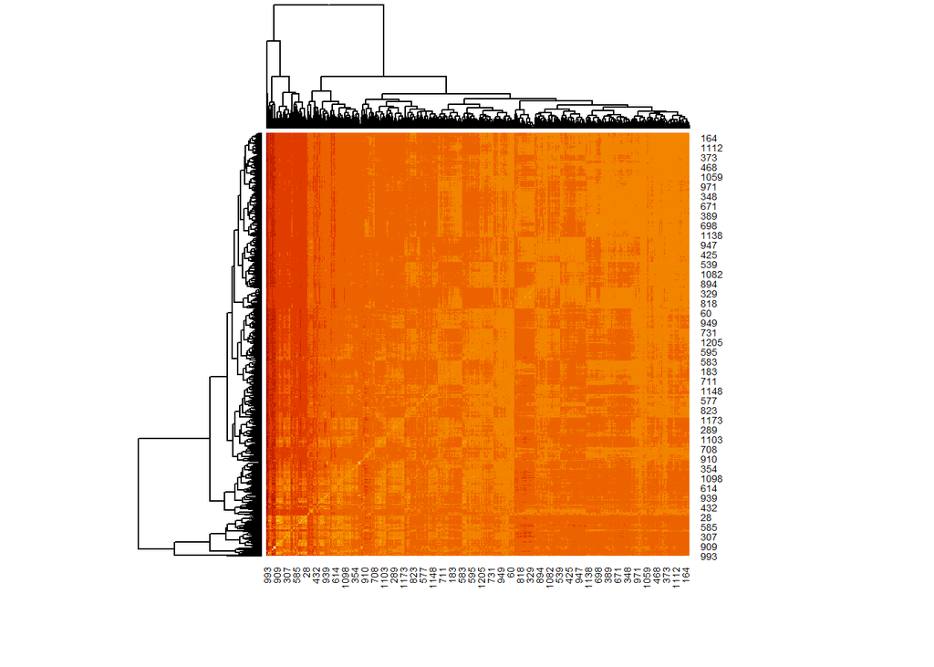

```r
l <- as.matrix(distanci)
heatmap(l)
```

## modetodo de particionamiento

## BUSCANDO k optimo

### METODO SILUETA

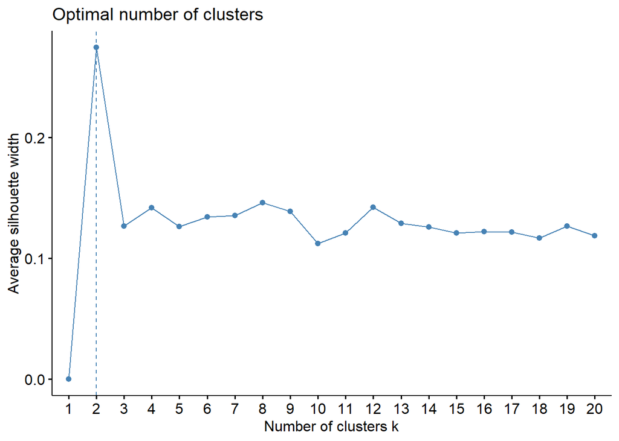

```r
kotimo <- scale(clus) # ESTANDARIZA LSO DATOS
set.seed(2021)
factoextra::fviz_nbclust(
  kotimo, kmeans, method = "silhouette", k.max = 20
) #SILUETA
```

[output not shown]

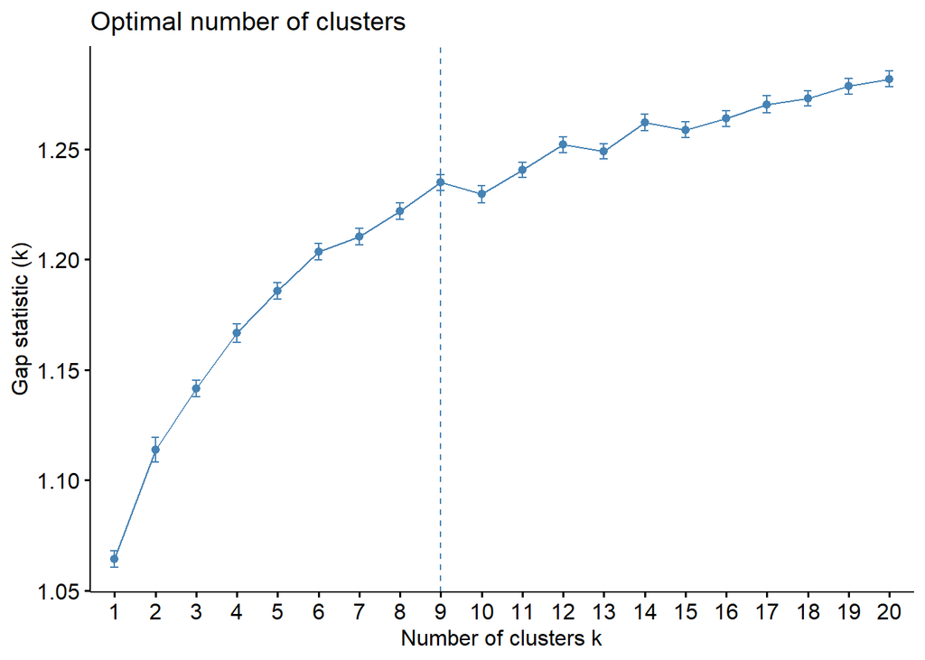

```r
set.seed(2021)
factoextra::fviz_nbclust(
  kotimo, kmeans, method = "gap_stat", k.max = 20
)
```

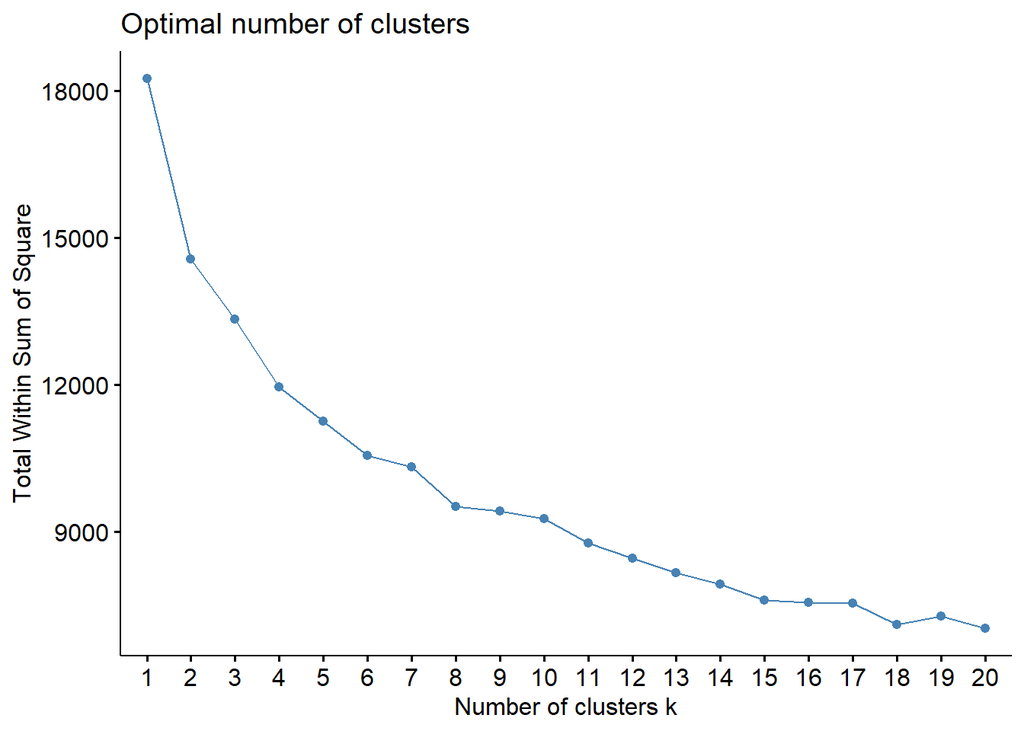

```r
set.seed(2021)
factoextra::fviz_nbclust(
  kotimo, kmeans, method = "wss", k.max = 20
)
```

## Cargamos nuestro dataset

#Realizamos una pequeña limpieza de los nombre duplicados y pasamos los nombres de los restaurantes como identificador de cada fila

```r
library(textshape)
base_datos<-read_excel("C:/Users/KEVIN/Downloads/eda/restaurantes3.xlsx")
base_datos<- base_datos[!duplicated(base_datos$name), ]
base_datos<-textshape::column_to_rownames(base_datos, loc = 2)
```

## Filtramos las variables que usaremos y las estandarizaremos

```r
df <- as.data.frame(base_datos)
df <- subset(df, select = c(enfado,anticipacion,disgusto,temor,
                            alegria,tristesa,sorpresa,confianza,negative,positive))
df<-scale(df)
head(df)
```

```
##                                 enfado anticipacion    disgusto      temor
## .20 Café & Burger            0.6463981  -0.44425629  0.22552379  0.3743255
## 14 de Garzon                -0.5230596  -0.50430824  0.15570074  1.1839539
## 3 Continentes Restaurant    -0.5230596   2.00586336 -0.61235273  1.5401904
## 401 RESTAURANTE              0.4664815   0.05463685  0.09661971 -0.5972286
## 50/50 Barra Restaurante     -0.5230596  -0.17402250 -0.61235273  2.0745451
## A la Carrera - Barra fusión -0.5230596  -0.28411775 -0.61235273 -0.5972286
##                                alegria     tristesa   sorpresa  confianza
## .20 Café & Burger            0.1278342  0.122423413  0.3474579 -0.5069335
## 14 de Garzon                 0.5097581 -0.732706638  0.2586715 -0.1188966
## 3 Continentes Restaurant    -1.5908234  1.148579473 -0.7179791 -0.4034570
## 401 RESTAURANTE              0.3481749 -0.009135057 -0.7179791  0.2094423
## 50/50 Barra Restaurante     -0.8031053  0.443097181  0.7469968 -0.1188966
## A la Carrera - Barra fusión  1.9101458  0.312452313 -0.7179791 -0.2769857
##                               negative   positive
## .20 Café & Burger           -0.1002306  0.1660452
## 14 de Garzon                -0.2471677  0.3006471
## 3 Continentes Restaurant     0.7813921 -0.6415657
## 401 RESTAURANTE              0.2203595 -0.1276315
## 50/50 Barra Restaurante      1.9568890 -1.7183803
## A la Carrera - Barra fusión -0.9818533  0.9736562
```

## Calculamos la matriz de distacias

[figure not shown]

```r
m.distancia <- get_dist(df, method = "euclidean")
fviz_dist(m.distancia, gradient = list(low = "blue", mid = "white",
                                       high = "red"))
```

## Estimamos el número de clústers optimos

```r
resnumclust<-NbClust::NbClust(data=df, distance = "euclidean", min.nc=2,
                     max.nc=10, method = "kmeans")
```

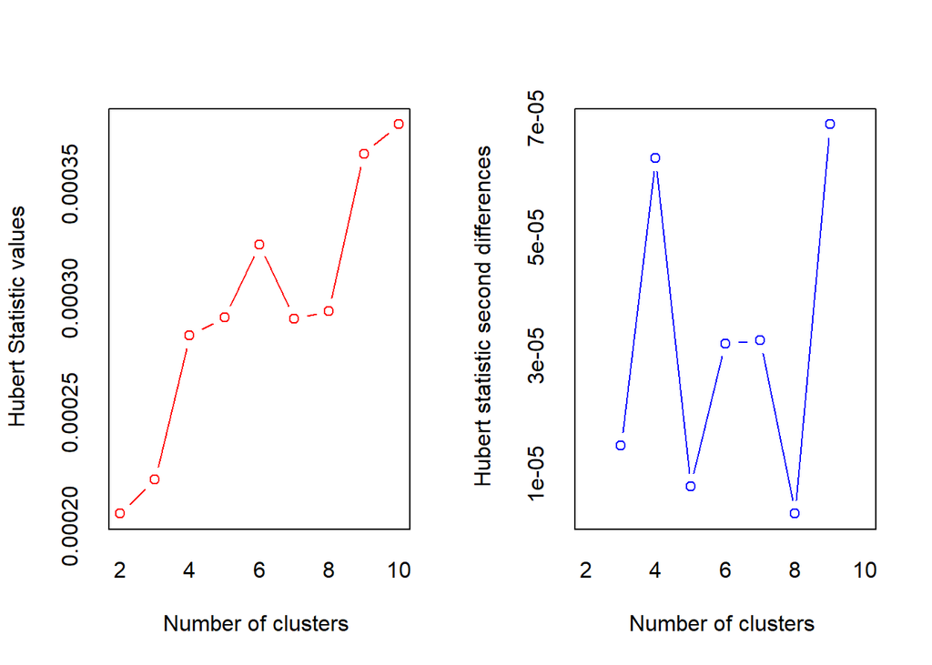

```
## *** : The Hubert index is a graphical method of determining the number of clusters.
##                 In the plot of Hubert index, we seek a significant knee that corresponds to a
##                 significant increase of the value of the measure i.e the significant peak in Hubert
##                 index second differences plot.
##
```

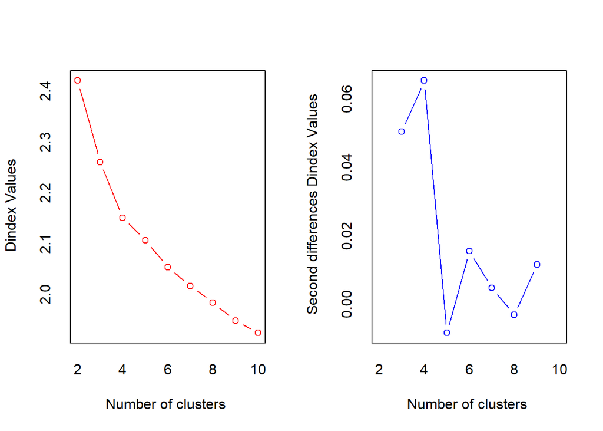

```
## *** : The D index is a graphical method of determining the number of clusters.
##                 In the plot of D index, we seek a significant knee (the significant peak in Dindex
##                 second differences plot) that corresponds to a significant increase of the value of
##                 the measure.
##
## * Among all indices:
## * 11 proposed 2 as the best number of clusters
## * 3 proposed 3 as the best number of clusters
## * 5 proposed 6 as the best number of clusters
## * 1 proposed 8 as the best number of clusters
## * 2 proposed 9 as the best number of clusters
## * 2 proposed 10 as the best number of clusters
##
##                    ***** Conclusion *****
##
## * According to the majority rule, the best number of clusters is  2
##
##
```

```
## Among all indices:
## ===================
## * 2 proposed  0 as the best number of clusters
## * 11 proposed  2 as the best number of clusters
## * 3 proposed  3 as the best number of clusters
## * 5 proposed  6 as the best number of clusters
## * 1 proposed  8 as the best number of clusters
## * 2 proposed  9 as the best number of clusters
## * 2 proposed  10 as the best number of clusters
##
## Conclusion
## =========================
## * According to the majority rule, the best number of clusters is  2 .
```

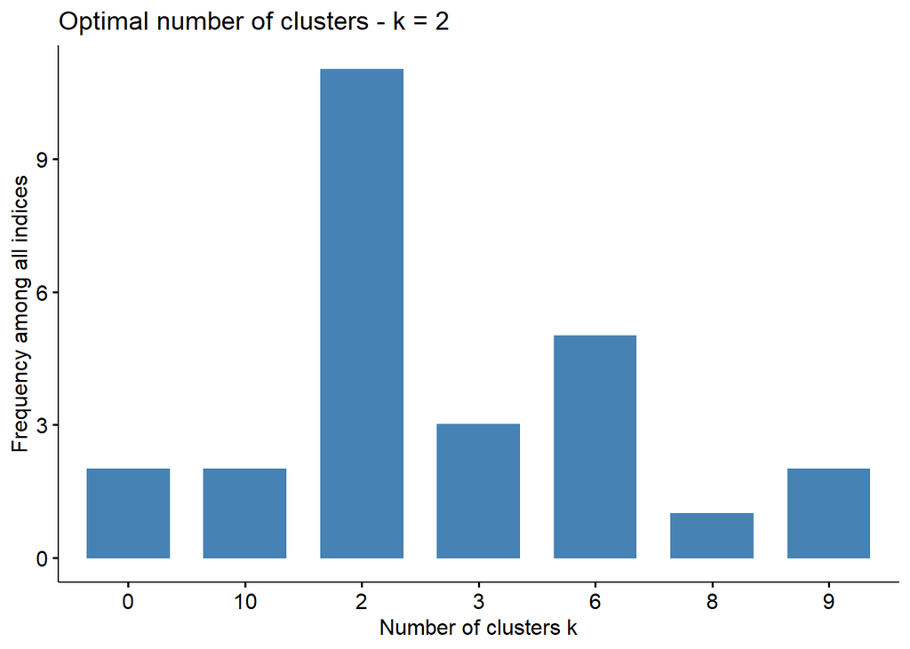

```r
factoextra::fviz_nbclust(resnumclust)
```

## Generamos los dos clusters

```r
set.seed(2021)
k2 <- kmeans(df, centers = 2, nstart = 200)
k2$cluster
```

[output not shown]

[output cut: 2121 more lines]

[output not shown]

```r
k2$withinss
```

```
## [1] 4269.446 3967.671
```

## valor de silueta

```
##   cluster size ave.sil.width
## 1       1  374          0.11
## 2       2  714          0.37
```

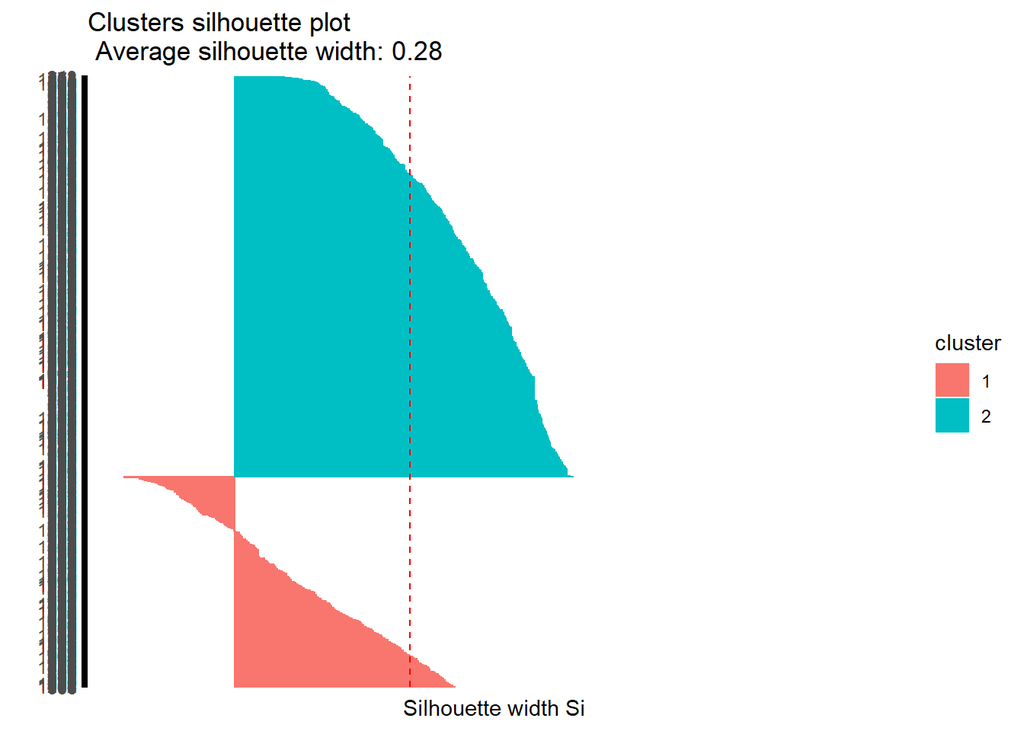

```r
siluet <- cluster::silhouette(k2$cluster,dist(df))

factoextra::fviz_silhouette(siluet)+
  coord_flip()
```

## Ploteos de los clusters

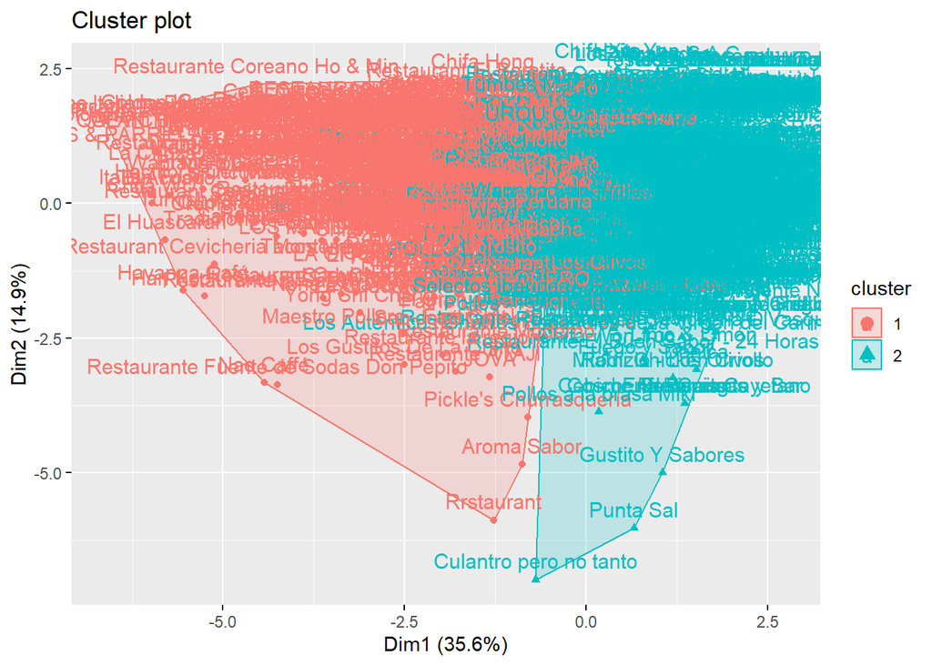

```r
library(factoextra)
fviz_cluster(k2, data = df)
```

```r
#fviz_cluster(k2, data = df, ellipse.type = "euclid",repel =TRUE,
#            star.plot = TRUE)
#fviz_cluster(k2, data = df, ellipse.type = "norm")

#res2 <- hcut(df, k = 2, stand = TRUE)
#fviz_dend(res2, rect = TRUE, cex = 0.5,
 #         k_colors = c("red","#2E9FDF"))
```

## Pasar los cluster al df inicial para que se pueda trabajar con ellos

```r
base_datos %>%
  mutate(Cluster = k2$cluster) %>%
  group_by(Cluster) %>%
  summarise_all("mean")
```

```
## # A tibble: 2 x 24
##   Cluster    id     x     y district direction n_reviews min_price max_price
##     <int> <dbl> <dbl> <dbl>    <dbl>     <dbl>     <dbl>     <dbl>     <dbl>
## 1       1    NA    NA -77.0       NA        NA        NA        NA        NA
## 2       2    NA    NA -77.0       NA        NA        NA        NA        NA
## # ... with 15 more variables: enfado <dbl>, anticipacion <dbl>, disgusto <dbl>,
## #   temor <dbl>, alegria <dbl>, tristesa <dbl>, sorpresa <dbl>,
## #   confianza <dbl>, negative <dbl>, positive <dbl>, stars_1 <dbl>,
## #   stars_2 <dbl>, stars_3 <dbl>, stars_4 <dbl>, stars_5 <dbl>
```

```r
df2 <- base_datos
df2 <- scale(df)
df2<- as.data.frame(df)
df2$clus<-as.factor(k2$cluster)
```

## giramos la base de datos de manera longitudinal de manera que se pueda apreciar el cluster, la emocion y los valores que le hemos asigando

```r
df2$clus<-factor(df2$clus)
data_long <- gather(df2, emocion, valor, enfado:positive, factor_key=TRUE)
head(data_long)
```

```
##   clus emocion      valor
## 1    2  enfado  0.6463981
## 2    2  enfado -0.5230596
## 3    1  enfado -0.5230596
## 4    2  enfado  0.4664815
## 5    1  enfado -0.5230596
## 6    2  enfado -0.5230596
```

## En este plot podemos observar las relaciones de los valores de cada cluster y las emociones

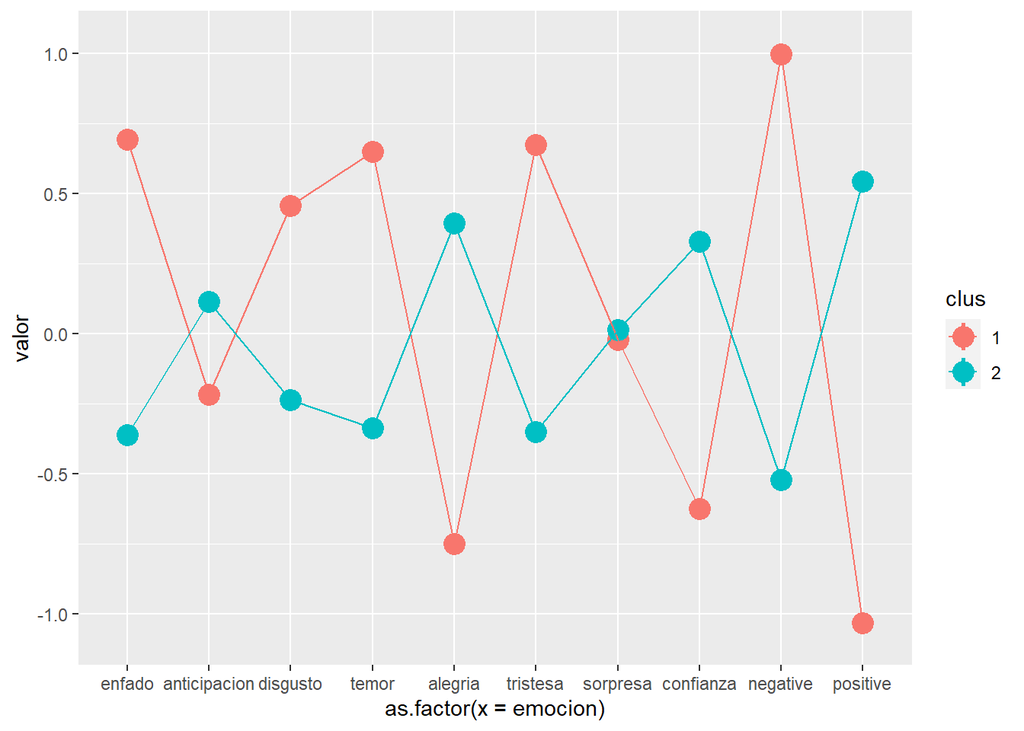

```r
ggplot(data_long, aes(as.factor(x = emocion), y = valor,group=clus, colour = clus)) +
  stat_summary(fun = mean, geom="pointrange", size = 1)+
  stat_summary(geom="line")
```

```r
geom_point(aes(shape=clus))
```

```
## mapping: shape = ~clus
## geom_point: na.rm = FALSE
## stat_identity: na.rm = FALSE
## position_identity
```